# TSIRO Baseline Data Analysis

#### Trees?

I considered theming my article around trees. While I didn’t go in that direction, it did help me sort out the forestry-related variables.

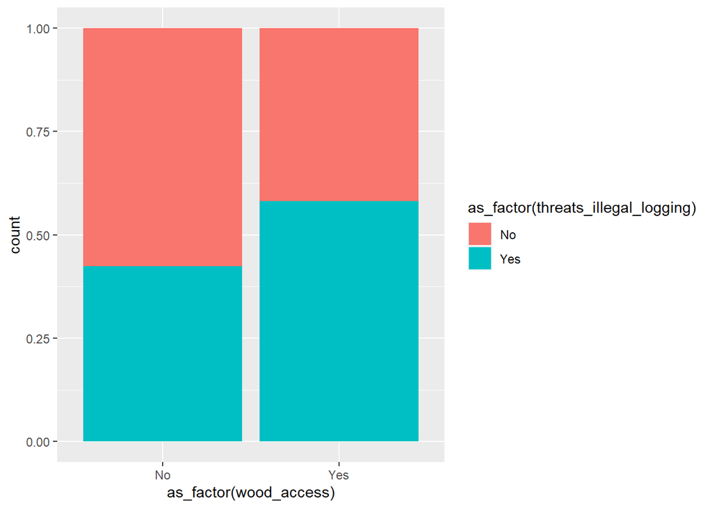

```r
final%>%
  drop_na(threats_illegal_logging, wood_access)%>%
  ggplot(aes(as_factor(wood_access), fill = as_factor(threats_illegal_logging)))+
  geom_bar(position = "fill")
```

```r
final%>%
  group_by(wood_access)%>%
  summarise(mean(threats_illegal_logging, na.rm = TRUE))
```

```
## # A tibble: 3 x 2
##   wood_access `mean(threats_illegal_logging, na.rm = TRUE)`
##   <dbl+lbl>                                           <dbl>
## 1  0 [No]                                             0.424
## 2  1 [Yes]                                            0.582
## 3 NA                                                  0.503
```

```r
# significance tests

summary(lm(wood_access ~ threats_illegal_logging, data = final))
```

```
##
## Call:
## lm(formula = wood_access ~ threats_illegal_logging, data = final)
##
## Residuals:
##     Min      1Q  Median      3Q     Max
## -0.5329 -0.3765 -0.3765  0.4671  0.6235
##
## Coefficients:
##                         Estimate Std. Error t value Pr(>|t|)
## (Intercept)              0.37647    0.03782   9.953  < 2e-16 ***
## threats_illegal_logging  0.15646    0.05373   2.912  0.00383 **
## ---
## Signif. codes:  0 '***' 0.001 '**' 0.01 '*' 0.05 '.' 0.1 ' ' 1
##
## Residual standard error: 0.4932 on 335 degrees of freedom
##   (418 observations deleted due to missingness)
## Multiple R-squared:  0.02469,    Adjusted R-squared:  0.02178
## F-statistic:  8.48 on 1 and 335 DF,  p-value: 0.003832
```

```r
# correlation between whether they've had trouble getting wood and whether they think the environment is threatened by illegal logging
summary(lm(wood ~ threats_illegal_logging, data = final))
```

```
##
## Call:
## lm(formula = wood ~ threats_illegal_logging, data = final)
##
## Residuals:
##     Min      1Q  Median      3Q     Max
## -0.4471 -0.4471 -0.3772 -0.3772  2.6227
##
## Coefficients:
##                         Estimate Std. Error t value Pr(>|t|)
## (Intercept)              1.44706    0.07345  19.701   <2e-16 ***
## threats_illegal_logging -0.06981    0.10434  -0.669    0.504
## ---
## Signif. codes:  0 '***' 0.001 '**' 0.01 '*' 0.05 '.' 0.1 ' ' 1
##
## Residual standard error: 0.9577 on 335 degrees of freedom
##   (418 observations deleted due to missingness)
## Multiple R-squared:  0.001335,   Adjusted R-squared:  -0.001647
## F-statistic: 0.4477 on 1 and 335 DF,  p-value: 0.5039
```

```r
# no correlation between how important wood is to their livelihood and whether they think the environment is threatened by illegal logging
summary(lm(trees_plant ~ threats_illegal_logging, data = final))
```

```
##
## Call:
## lm(formula = trees_plant ~ threats_illegal_logging, data = final)
##
## Residuals:
##     Min      1Q  Median      3Q     Max
## -0.6038 -0.4765  0.3962  0.3962  0.5235
##
## Coefficients:
##                         Estimate Std. Error t value Pr(>|t|)
## (Intercept)              0.47649    0.02772  17.189  < 2e-16 ***
## threats_illegal_logging  0.12728    0.03923   3.244  0.00124 **
## ---
## Signif. codes:  0 '***' 0.001 '**' 0.01 '*' 0.05 '.' 0.1 ' ' 1
##
## Residual standard error: 0.4951 on 635 degrees of freedom
##   (118 observations deleted due to missingness)
## Multiple R-squared:  0.01631,    Adjusted R-squared:  0.01476
## F-statistic: 10.53 on 1 and 635 DF,  p-value: 0.001239
```

```r
# positive correlation
summary(lm(trees_why_perm ~ threats_illegal_logging, data = final))
```

```
##
## Call:
## lm(formula = trees_why_perm ~ threats_illegal_logging, data = final)
##
## Residuals:
##     Min      1Q  Median      3Q     Max
## -0.8594  0.1406  0.1406  0.2763  0.2763
##
## Coefficients:
##                         Estimate Std. Error t value Pr(>|t|)
## (Intercept)              0.72368    0.03211  22.538  < 2e-16 ***
## threats_illegal_logging  0.13569    0.04298   3.157  0.00174 **
## ---
## Signif. codes:  0 '***' 0.001 '**' 0.01 '*' 0.05 '.' 0.1 ' ' 1
##
## Residual standard error: 0.3959 on 342 degrees of freedom
##   (411 observations deleted due to missingness)
## Multiple R-squared:  0.02832,    Adjusted R-squared:  0.02548
## F-statistic: 9.967 on 1 and 342 DF,  p-value: 0.001735
```

```r
# positive correlation
summary(lm(trees_why_cut ~ threats_illegal_logging, data = final))
```

```
##
## Call:
## lm(formula = trees_why_cut ~ threats_illegal_logging, data = final)
##
## Residuals:
##     Min      1Q  Median      3Q     Max
## -0.6510 -0.5921  0.3490  0.4079  0.4079
##
## Coefficients:
##                         Estimate Std. Error t value Pr(>|t|)
## (Intercept)              0.59211    0.03931   15.06   <2e-16 ***
## threats_illegal_logging  0.05894    0.05262    1.12    0.263
## ---
## Signif. codes:  0 '***' 0.001 '**' 0.01 '*' 0.05 '.' 0.1 ' ' 1
##
## Residual standard error: 0.4846 on 342 degrees of freedom
##   (411 observations deleted due to missingness)
## Multiple R-squared:  0.003655,   Adjusted R-squared:  0.0007417
## F-statistic: 1.255 on 1 and 342 DF,  p-value: 0.2635
```

```r
# no significant correlation
summary(lm(wood_access ~ clear_where_a, data = final))
```

```
##
## Call:
## lm(formula = wood_access ~ clear_where_a, data = final)
##
## Residuals:
##     Min      1Q  Median      3Q     Max
## -0.4516 -0.4516 -0.3488  0.5484  0.6512
##
## Coefficients:
##               Estimate Std. Error t value Pr(>|t|)
## (Intercept)    0.45161    0.03368  13.409   <2e-16 ***
## clear_where_a -0.10278    0.08282  -1.241    0.216
## ---
## Signif. codes:  0 '***' 0.001 '**' 0.01 '*' 0.05 '.' 0.1 ' ' 1
##
## Residual standard error: 0.4961 on 258 degrees of freedom
##   (495 observations deleted due to missingness)
## Multiple R-squared:  0.005934,   Adjusted R-squared:  0.002081
## F-statistic:  1.54 on 1 and 258 DF,  p-value: 0.2157
```

```r
# no significant correlation between difficulty collecting firewood and plans to clear forest
summary(lm(clear_where_a ~ threats_illegal_logging, data = final))
```

```
##
## Call:
## lm(formula = clear_where_a ~ threats_illegal_logging, data = final)
##
## Residuals:
##     Min      1Q  Median      3Q     Max
## -0.1206 -0.1206 -0.1024 -0.1024  0.8976
##
## Coefficients:
##                         Estimate Std. Error t value Pr(>|t|)
## (Intercept)              0.12060    0.02235   5.397 1.16e-07 ***
## threats_illegal_logging -0.01816    0.03137  -0.579    0.563
## ---
## Signif. codes:  0 '***' 0.001 '**' 0.01 '*' 0.05 '.' 0.1 ' ' 1
##
## Residual standard error: 0.3153 on 402 degrees of freedom
##   (351 observations deleted due to missingness)
## Multiple R-squared:  0.0008331,  Adjusted R-squared:  -0.001652
## F-statistic: 0.3352 on 1 and 402 DF,  p-value: 0.5629
```

```r
# absolutely no correlation between threat of illegal logging and plan to clear land
```

#### Corrplots

Coming up empty, I made a ton of corrplots to try to find some significant correlations.

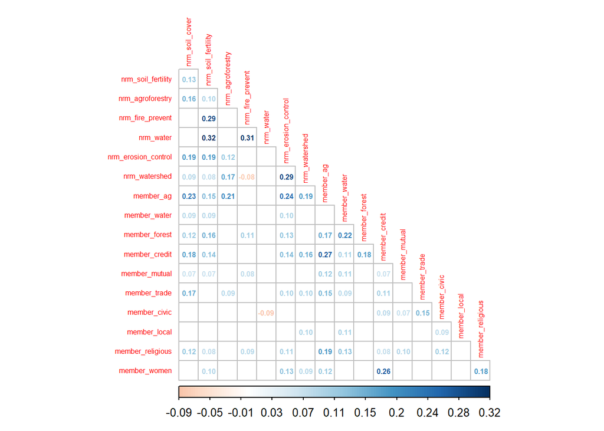

```r
# group membership vs. natural resource management practices - ended up informing the article

correlations_final <- final%>%
  mutate(member_sum = rowSums(select(final, member_ag:member_other2), na.rm = TRUE), .after = member_other2)%>%
  select(nrm_pract_a:nrm_pract_g, member_ag:member_women)%>%
  replace(is.na(.), 0)%>%
  rename(nrm_soil_cover = nrm_pract_a,
         nrm_soil_fertility = nrm_pract_b,
         nrm_agroforestry = nrm_pract_c,
         nrm_fire_prevent = nrm_pract_d,
         nrm_water = nrm_pract_e,
         nrm_erosion_control = nrm_pract_f,
         nrm_watershed = nrm_pract_g)%>%
  view()

M <- cor(correlations_final)

testRes <- cor.mtest(correlations_final, conf.level = 0.95)

corrplot(M, method = 'number', p.mat = testRes$p, tl.cex = 0.5, insig = 'blank', pch.cex = 0.8, pch.col = 'grey20', number.cex = 0.5, diag = FALSE, type = 'lower', is.corr = FALSE)
```

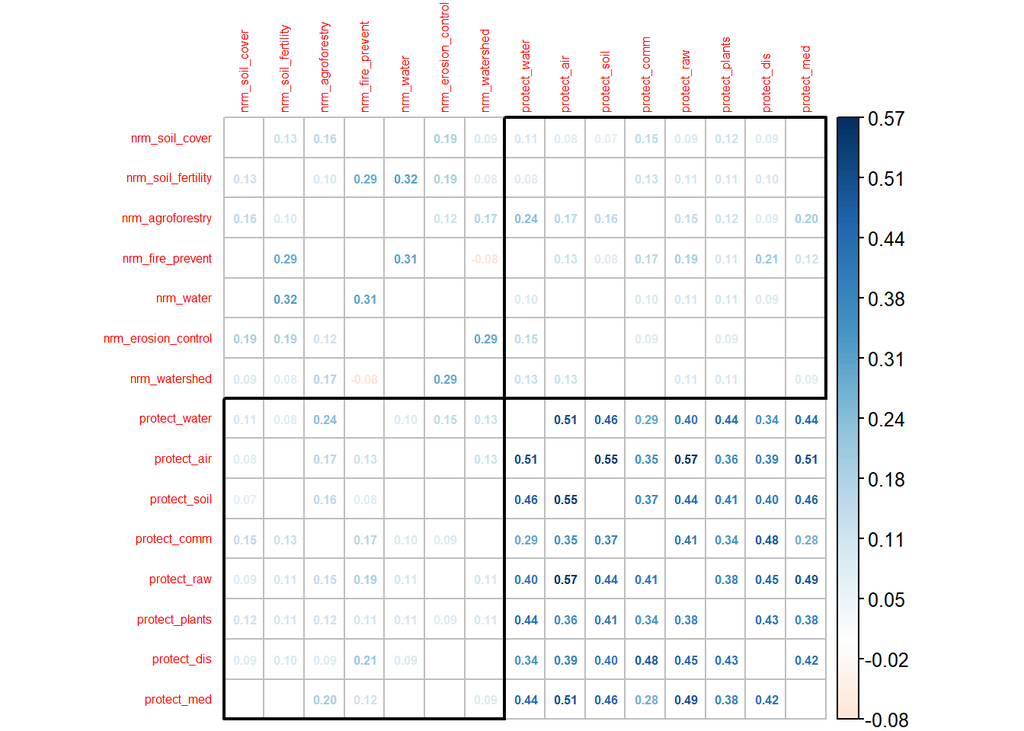

```r
# members of agriculture groups were more likely to engage in natural resource managment practices than those who aren't.


# natural resource management practices vs. views.  I didn't find the strong correlation between specific resource types that I was hoping for, but there was a broader beliefs-action correlation explored more later.

correlations_final2 <- final%>%
  select(nrm_pract_a:nrm_pract_g, protect_water:protect_med)%>%
  replace(is.na(.), 0)%>%
  rename(nrm_soil_cover = nrm_pract_a,
         nrm_soil_fertility = nrm_pract_b,
         nrm_agroforestry = nrm_pract_c,
         nrm_fire_prevent = nrm_pract_d,
         nrm_water = nrm_pract_e,
         nrm_erosion_control = nrm_pract_f,
         nrm_watershed = nrm_pract_g)%>%
  view()

M2 <- cor(correlations_final2)

testRes2 <- cor.mtest(correlations_final2, conf.level = 0.95)

r = rbind(c('protect_water', 'nrm_soil_cover', 'protect_med', 'nrm_watershed'),
          c('nrm_soil_cover', 'protect_water', 'nrm_watershed', 'protect_med'))

corrplot(M2, method = 'number', p.mat = testRes2$p, tl.cex = 0.5, insig = 'blank', pch.cex = 0.8, number.cex = 0.5, diag = FALSE, is.corr = FALSE)%>%
  corrRect(namesMat = r)
```

#### Lasso regressions - starting with threats

A lasso regression takes one response variable and a whole load of potential indicator variables and finds which of them can actually be combined to predict the response. I sometimes used this in reverse to find what outcomes could be predicted by one indicator.

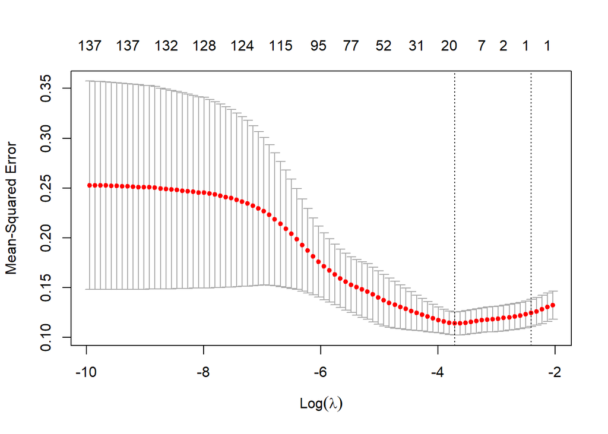

```r
y <- final$threats

final_predict <- final%>%
  select(gender_hh_type:member_other2, trees_a:trees_y, trees_why_a:trees_why_k, trees_why_perm:land, land_kind_a:land_kind_b, clear, clear_why_a:clear_why_z, clear_where_a:clear_where_z, clear_protect:honey_why, mush:mush_why, insects:insects_why, fruits:fruits_why, meat:meat_why, plants:plants_why, fish:fish_why, wood:wood_why, char:char_why, protect_water:loss, threats, threats_illegal_logging:threats_resource_use, fuel_sources_1:fuel_sources_6, fuel_sources2_1:fuel_women_hours, ppi:mddw, -starts_with("threat"))%>%
  replace(is.na(.), 0)%>%
  na.omit(.)
x <- data.matrix(final_predict)

cv_model <- cv.glmnet(x, y, alpha = 1)
best_lambda <- cv_model$lambda.min
plot(cv_model)
```

```r
best_model <- glmnet(x, y, alpha = 1, lambda = best_lambda)
coef(best_model)
```

```
## 153 x 1 sparse Matrix of class "dgCMatrix"
##                             s0
## (Intercept)       5.208171e-01
## gender_hh_type    .
## ed_level_head     .
## work_head         .
## paid_head         9.401194e-03
## read_head         .
## fokontany_deid    .
## nrm_pract_a       .
## nrm_pract_b       .
## nrm_pract_c       2.390598e-02
## nrm_pract_d       .
## nrm_pract_e       .
## nrm_pract_f       .
## nrm_pract_g       .
## nrm_pract_sum     .
## nrm_pract_y       .
## loan_ngo          .
## loan_informal     .
## loan_formal       .
## loan_friend       .
## loan_group        .
## loan_sav          .
## member_ag         .
## member_water      .
## member_forest     .
## member_credit     .
## member_mutual     .
## member_trade      .
## member_civic      .
## member_local      .
## member_religious  1.967516e-02
## member_women      .
## member_other      .
## member_other2     .
## trees_a           .
## trees_b          -1.840578e-02
## trees_c           .
## trees_d           .
```

[output cut: 100 more lines]

```
## fuel_men_hours    .
## fuel_women_hours  .
## ppi               4.732050e-04
## fies_enough       .
## fies_healthy      .
## fies_few          .
## fies_skip         .
## fies_less         .
## fies_no           .
## fies_hungry       .
## fies_day         -3.668740e-02
## fies_unw_avg      .
## CSI               .
## birth             .
## mddw              .
```

```r
as.data.frame(as.matrix(coef(best_model)))%>%
  arrange(desc(s0))
```

```
##                             s0
## (Intercept)       5.208171e-01
## loss              2.129509e-01
## protect_avg       4.910828e-02
## nrm_pract_c       2.390598e-02
## clear             2.217348e-02
## clear_why_b       2.042835e-02
## member_religious  1.967516e-02
## trees_why_i       1.832400e-02
## paid_head         9.401194e-03
## protect_plants    6.676506e-03
## trees_why_h       3.293188e-03
## clear_why_c       1.285893e-03
## trees_why_j       6.011270e-04
## ppi               4.732050e-04
## trees_why_b       8.321097e-05
## gender_hh_type    0.000000e+00
## ed_level_head     0.000000e+00
## work_head         0.000000e+00
## read_head         0.000000e+00
## fokontany_deid    0.000000e+00
## nrm_pract_a       0.000000e+00
## nrm_pract_b       0.000000e+00
## nrm_pract_d       0.000000e+00
## nrm_pract_e       0.000000e+00
## nrm_pract_f       0.000000e+00
## nrm_pract_g       0.000000e+00
## nrm_pract_sum     0.000000e+00
## nrm_pract_y       0.000000e+00
## loan_ngo          0.000000e+00
## loan_informal     0.000000e+00
## loan_formal       0.000000e+00
## loan_friend       0.000000e+00
## loan_group        0.000000e+00
## loan_sav          0.000000e+00
## member_ag         0.000000e+00
## member_water      0.000000e+00
## member_forest     0.000000e+00
## member_credit     0.000000e+00
## member_mutual     0.000000e+00
```

[output cut: 99 more lines]

```
## fies_healthy      0.000000e+00
## fies_few          0.000000e+00
## fies_skip         0.000000e+00
## fies_less         0.000000e+00
## fies_no           0.000000e+00
## fies_hungry       0.000000e+00
## fies_unw_avg      0.000000e+00
## CSI               0.000000e+00
## birth             0.000000e+00
## mddw              0.000000e+00
## fuel_sources2_1  -1.276538e-02
## trees_b          -1.840578e-02
## clear_why_z      -2.424997e-02
## fies_day         -3.668740e-02
## trees_why_k      -4.894531e-02
```

## Membership Analysis

I looked into group membership with a lasso regression and found several leads worth pursuing, detailed below.

#### Effects of membership in any group

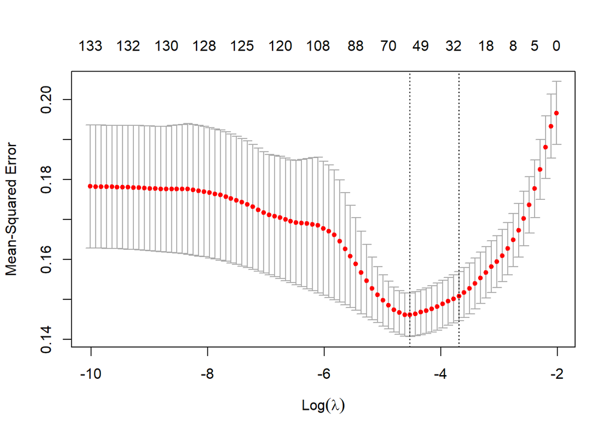

```r
# adding membership info into the most recent dataset

final_member <- final%>%
  mutate(across(member_ag:member_other2, ~replace_na(.,0)))

final_member<- final_member%>%
  mutate(threats_sum = rowSums(select(final_member, threats_illegal_logging:threats_resource_use), na.rm = TRUE), .after = threats_other_EN)%>%
  mutate(member_sum = rowSums(select(final_member, member_ag:member_other2)), .after = member_other2)%>%
  mutate(member_any = ifelse((member_sum>0), 1, 0))%>%
  mutate(probability_not_in_poverty = (100-ppi)/100, .after = ppi)%>%
  mutate(how_food_secure = 1-fies_unw_avg, .after = fies_unw_avg)

y <- final_member$member_any

final_predict <- final_member%>%
  select(gender_hh_type:member_other2, trees_a:trees_y, trees_why_a:trees_why_k, trees_why_perm:land, land_kind_a:land_kind_b, clear, clear_why_a:clear_why_z, clear_where_a:clear_where_z, clear_protect:honey_why, mush:mush_why, insects:insects_why, fruits:fruits_why, meat:meat_why, plants:plants_why, fish:fish_why, wood:wood_why, char:char_why, protect_water:loss, threats, threats_illegal_logging:threats_resource_use, fuel_sources_1:fuel_sources_6, fuel_sources2_1:fuel_women_hours, ppi:mddw, -starts_with("member"), -probability_not_in_poverty, -how_food_secure)%>%
  replace(is.na(.), 0)%>%
  na.omit(.)
x <- data.matrix(final_predict)

cv_model <- cv.glmnet(x, y, alpha = 1)
best_lambda <- cv_model$lambda.min
plot(cv_model)
```

```r
best_model <- glmnet(x, y, alpha = 1, lambda = best_lambda)
coef(best_model)
```

```
## 151 x 1 sparse Matrix of class "dgCMatrix"
##                                         s0
## (Intercept)                   3.219006e-01
## gender_hh_type                .
## ed_level_head                 1.027954e-02
## work_head                     8.986719e-02
## paid_head                     1.544045e-02
## read_head                     1.135952e-01
## fokontany_deid                .
## nrm_pract_a                   3.797317e-03
## nrm_pract_b                   2.448515e-02
## nrm_pract_c                   .
## nrm_pract_d                   .
## nrm_pract_e                  -2.945190e-02
## nrm_pract_f                   6.701060e-02
## nrm_pract_g                   .
## nrm_pract_sum                 1.053932e-02
## nrm_pract_y                   .
## loan_ngo                      .
## loan_informal                 .
## loan_formal                  -4.300666e-04
## loan_friend                   .
## loan_group                   -5.265513e-02
## loan_sav                      .
## trees_a                      -7.320422e-02
## trees_b                       9.971132e-02
## trees_c                       .
## trees_d                       3.027774e-02
## trees_y                       .
## trees_why_a                   .
## trees_why_b                   1.299743e-02
## trees_why_c                   9.542806e-02
## trees_why_d                   .
## trees_why_e                   3.550968e-02
## trees_why_f                   .
## trees_why_g                  -7.587503e-02
## trees_why_h                   .
## trees_why_i                   .
## trees_why_j                   .
## trees_why_k                  -5.914468e-03
```

[output cut: 98 more lines]

```
## fuel_men_hours                6.251486e-05
## fuel_women_hours              .
## ppi                           7.531595e-04
## fies_enough                   .
## fies_healthy                  .
## fies_few                      .
## fies_skip                    -3.404252e-02
## fies_less                    -1.551721e-02
## fies_no                       .
## fies_hungry                  -5.220390e-02
## fies_day                      .
## fies_unw_avg                  .
## CSI                           6.288684e-04
## birth                         .
## mddw                          5.969532e-02
```

```r
as.data.frame(as.matrix(coef(best_model)))%>%
  arrange(desc(s0))
```

```
##                                         s0
## (Intercept)                   3.219006e-01
## clear_why_z                   1.422052e-01
## read_head                     1.135952e-01
## trees_b                       9.971132e-02
## loss                          9.615857e-02
## trees_why_c                   9.542806e-02
## insects_access                9.415230e-02
## work_head                     8.986719e-02
## clear_why_f                   8.461927e-02
## fuel_sources_6                8.054339e-02
## trees_why_perm                6.775513e-02
## nrm_pract_f                   6.701060e-02
## mddw                          5.969532e-02
## threats                       5.684909e-02
## fuel_sources_5                5.518803e-02
## meat_access                   4.826503e-02
## land_kind_b                   4.212103e-02
## clear_where_b                 3.949374e-02
## protect_med                   3.896975e-02
## trees_why_e                   3.550968e-02
## trees_d                       3.027774e-02
## fish_access                   2.697276e-02
## protect_plants                2.666470e-02
## clear_why_c                   2.659342e-02
## threats_slash_burn            2.630573e-02
## wood_access                   2.489819e-02
## nrm_pract_b                   2.448515e-02
## wood_change                   1.663813e-02
## paid_head                     1.544045e-02
## trees_why_cut                 1.517043e-02
## trees_why_b                   1.299743e-02
## nrm_pract_sum                 1.053932e-02
## ed_level_head                 1.027954e-02
## plants_why                    9.137905e-03
## nrm_pract_a                   3.797317e-03
## threats_seine_fishing         3.352018e-03
## protect_soil                  1.805351e-03
## wood                          1.322362e-03
## ppi                           7.531595e-04
```

[output cut: 97 more lines]

```
## loan_formal                  -4.300666e-04
## fish                         -1.337946e-03
## trees_why_k                  -5.914468e-03
## mush                         -8.230634e-03
## fies_less                    -1.551721e-02
## insects                      -1.738406e-02
## fuel_sources2_1              -2.230466e-02
## threats_farming              -2.504619e-02
## nrm_pract_e                  -2.945190e-02
## fies_skip                    -3.404252e-02
## fies_hungry                  -5.220390e-02
## loan_group                   -5.265513e-02
## trees_a                      -7.320422e-02
## trees_why_g                  -7.587503e-02
## clear_where_c                -9.648562e-02
```

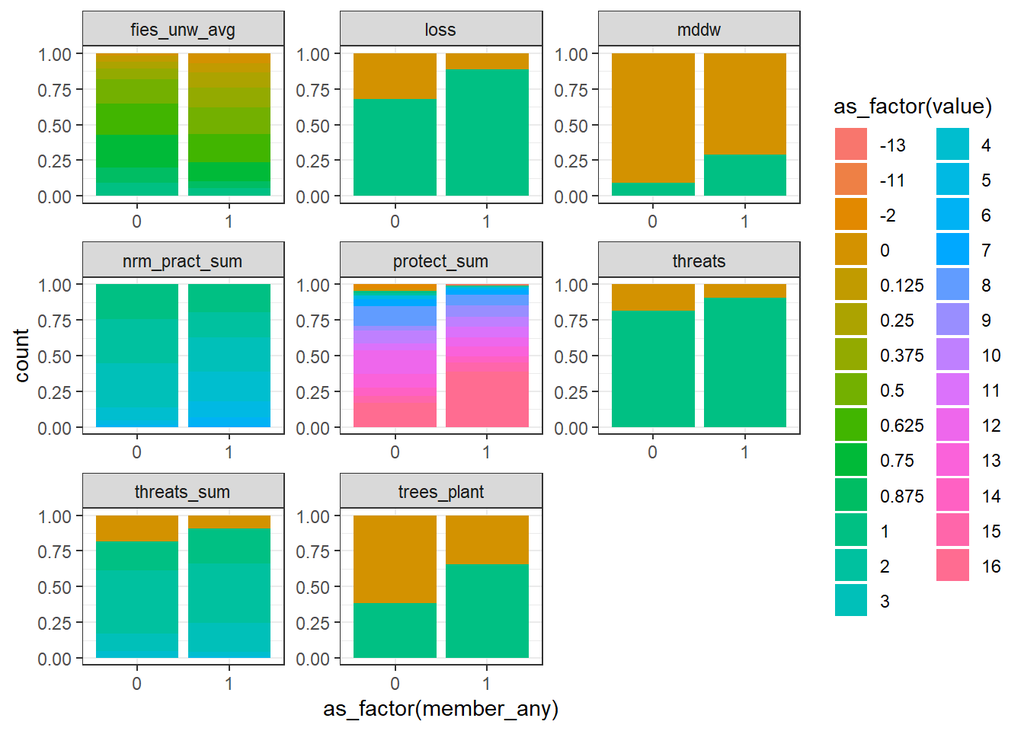

```r
final_member_compact <- final_member%>%
  select(member_sum, member_any, threats, threats_sum, protect_sum, nrm_pract_sum, trees_plant, loss, fies_unw_avg, how_food_secure, mddw, ppi, probability_not_in_poverty)%>%
  view()

final_member_compact %>%
  drop_na(.)%>%
  gather(threats, threats_sum, protect_sum, nrm_pract_sum, trees_plant, loss, fies_unw_avg, mddw, key = "var", value = "value") %>%
  ggplot(aes(x = as_factor(member_any), fill = as_factor(value))) +
    geom_bar(position = 'fill') +
    facet_wrap(~ var, scales = "free") +
    theme_bw()
```

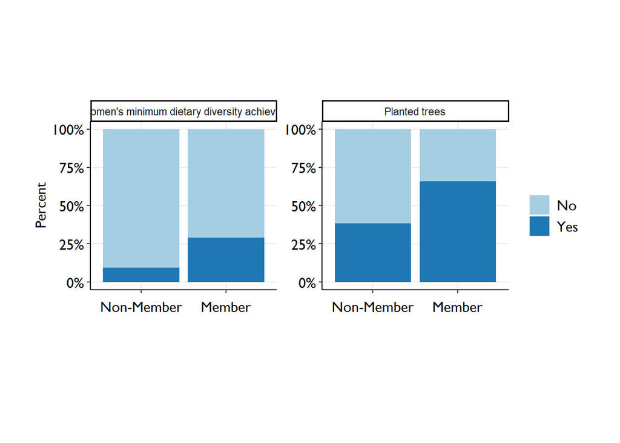

```r
fact_names <- as_labeller(c("mddw" = "Women's minimum dietary diversity achieved", "trees_plant" = "Planted trees"))

final_member_compact %>%
  drop_na(.)%>%
  gather(mddw, trees_plant, key = "var", value = "value") %>%
  ggplot(aes(x = as_factor(member_any), fill = as_factor(value))) +
    geom_bar(position = 'fill') +
    facet_wrap(~ var, scales = "free", labeller = fact_names) +
    scale_fill_brewer(palette = "Paired", name = "", labels = c("No", "Yes"))+
    labs(y = "Percent")+
    scale_y_continuous(labels = scales::percent)+
    theme_usaid()+
    scale_x_discrete(labels = c("Non-Member", "Member"), name = "")
```

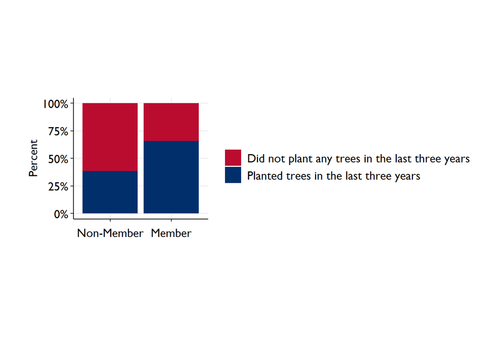

```r
final_member_compact %>%
  drop_na(.)%>%
  ggplot(aes(x = as_factor(member_any), fill = as_factor(trees_plant)))+
  geom_bar(position = 'fill')+
  theme_usaid()+
scale_y_continuous(labels = scales::percent)+
  labs(y = "Percent")+
  scale_x_discrete(labels = c("Non-Member", "Member"), name = "")+
  scale_fill_manual(values = c("#BA0C2F", "#002F6C"), name = "",
labels = c("Did not plant any trees in the last three years", "Planted trees in the last three years"))
```

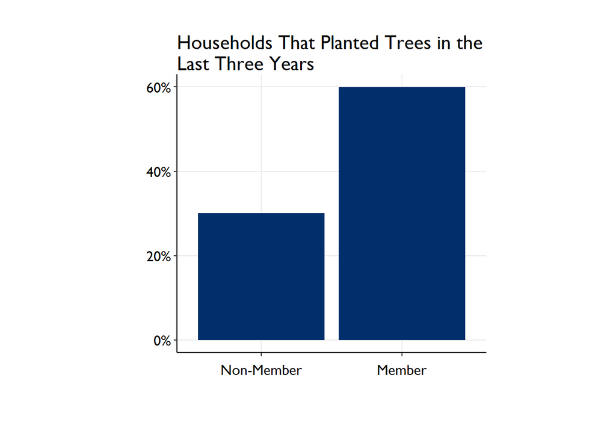

```r
final_member_compact %>%
  group_by(member_any)%>%
  summarize(trees_percent = mean(trees_plant, drop_na()))%>%
  ggplot(aes(x = as_factor(member_any), y = trees_percent))+
  geom_col(fill = "#002F6C")+
  theme_usaid()+
  coord_fixed(ratio = 4)+
  scale_y_continuous(labels = scales::percent)+
  labs(y = "")+
  scale_x_discrete(labels = c("Non-Member", "Member"), name = "")+
  labs(title = "Households That Planted Trees in the \nLast Three Years")
```

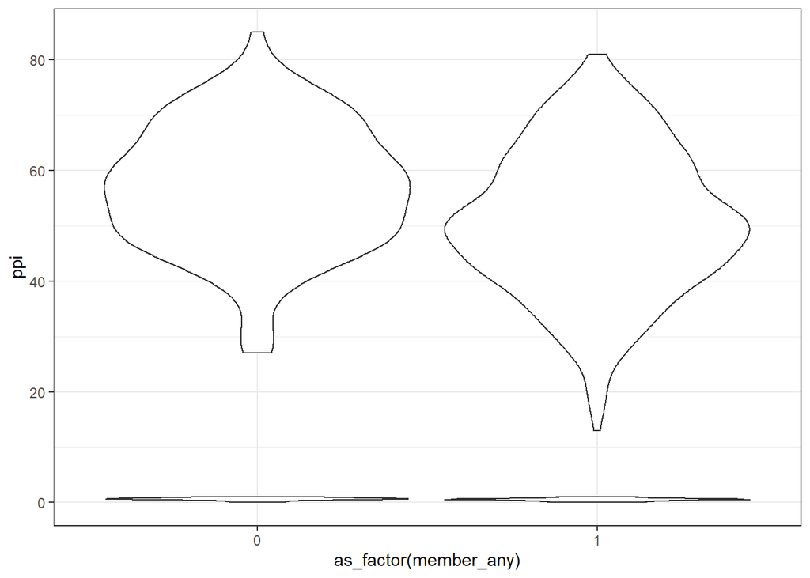

```r
ggsave("trees_plant_graph.png", width = 5)
final_member_compact%>%
  drop_na(ppi)%>%
  ggplot(aes(x = as_factor(member_any))) +
    geom_violin(aes(y = ppi))+
    geom_violin(aes(y = fies_unw_avg))+
    theme_bw()
```

```r
final_member%>%
  group_by(member_any)%>%
  filter(trees_plant == 1)%>%
  drop_na(trees_why_perm)%>%
  summarise(mean(trees_why_perm, drop.na = TRUE))
```

```
## # A tibble: 2 x 2
##   member_any `mean(trees_why_perm, drop.na = TRUE)`
##        <dbl>                                  <dbl>
## 1          0                                  0.541
## 2          1                                  0.828
```

```r
final_member%>%
  group_by(member_any)%>%
  filter(trees_plant == 1)%>%
  drop_na(trees_why_perm)%>%
  summarise(sum(trees_why_perm))
```

```
## # A tibble: 2 x 2
##   member_any `sum(trees_why_perm)`
##        <dbl>                 <dbl>
## 1          0                    33
## 2          1                   274
```

```r
final_member%>%
  group_by(member_any)%>%
  filter(trees_plant == 1)%>%
  drop_na(trees_why_cut)%>%
  summarise(mean(trees_why_cut, drop.na = TRUE))
```

```
## # A tibble: 2 x 2
##   member_any `mean(trees_why_cut, drop.na = TRUE)`
##        <dbl>                                 <dbl>
## 1          0                                 0.656
## 2          1                                 0.598
```

```r
view(final_member)
```

```r
summary(lm(threats ~ member_any, data = final_member))
```

```
##
## Call:
## lm(formula = threats ~ member_any, data = final_member)
##
## Residuals:
##     Min      1Q  Median      3Q     Max
## -0.8913  0.1087  0.1087  0.1087  0.2857
##
## Coefficients:
##             Estimate Std. Error t value Pr(>|t|)
## (Intercept)  0.71429    0.02492  28.666  < 2e-16 ***
## member_any   0.17702    0.02914   6.075 1.97e-09 ***
## ---
## Signif. codes:  0 '***' 0.001 '**' 0.01 '*' 0.05 '.' 0.1 ' ' 1
##
## Residual standard error: 0.355 on 753 degrees of freedom
## Multiple R-squared:  0.04671,    Adjusted R-squared:  0.04545
## F-statistic:  36.9 on 1 and 753 DF,  p-value: 1.973e-09
```

```r
summary(lm(threats_sum ~ member_any, data = final_member))
```

```
##
## Call:
## lm(formula = threats_sum ~ member_any, data = final_member)
##
## Residuals:
##     Min      1Q  Median      3Q     Max
## -1.7862 -0.7862  0.2138  0.6946  3.2138
##
## Coefficients:
##             Estimate Std. Error t value Pr(>|t|)
## (Intercept)  1.30542    0.07279  17.935  < 2e-16 ***
## member_any   0.48081    0.08513   5.648  2.3e-08 ***
## ---
## Signif. codes:  0 '***' 0.001 '**' 0.01 '*' 0.05 '.' 0.1 ' ' 1
##
## Residual standard error: 1.037 on 753 degrees of freedom
## Multiple R-squared:  0.04065,    Adjusted R-squared:  0.03937
## F-statistic:  31.9 on 1 and 753 DF,  p-value: 2.297e-08
```

```r
summary(lm(protect_sum ~ member_any, data = final_member))
```

```
##
## Call:
## lm(formula = protect_sum ~ member_any, data = final_member)
##
## Residuals:
##     Min      1Q  Median      3Q     Max
## -25.819  -2.819   1.181   3.181   5.025
##
## Coefficients:
##             Estimate Std. Error t value Pr(>|t|)
## (Intercept)  10.9754     0.2812  39.025  < 2e-16 ***
## member_any    1.8435     0.3289   5.605 2.93e-08 ***
## ---
## Signif. codes:  0 '***' 0.001 '**' 0.01 '*' 0.05 '.' 0.1 ' ' 1
##
## Residual standard error: 4.007 on 753 degrees of freedom
## Multiple R-squared:  0.04005,    Adjusted R-squared:  0.03877
## F-statistic: 31.41 on 1 and 753 DF,  p-value: 2.928e-08
```

```r
summary(lm(nrm_pract_sum ~ member_any, data = final_member))
```

```
##
## Call:
## lm(formula = nrm_pract_sum ~ member_any, data = final_member)
##
## Residuals:
##     Min      1Q  Median      3Q     Max
## -2.1558 -1.1558 -0.1558  0.8442  4.7277
##
## Coefficients:
##             Estimate Std. Error t value Pr(>|t|)
## (Intercept)   2.2723     0.1023  22.220  < 2e-16 ***
## member_any    0.8835     0.1195   7.392 3.86e-13 ***
## ---
## Signif. codes:  0 '***' 0.001 '**' 0.01 '*' 0.05 '.' 0.1 ' ' 1
##
## Residual standard error: 1.453 on 752 degrees of freedom
##   (1 observation deleted due to missingness)
## Multiple R-squared:  0.06774,    Adjusted R-squared:  0.0665
## F-statistic: 54.64 on 1 and 752 DF,  p-value: 3.855e-13
```

```r
summary(lm(trees_plant ~ member_any, data = final_member))
```

```
##
## Call:
## lm(formula = trees_plant ~ member_any, data = final_member)
##
## Residuals:
##     Min      1Q  Median      3Q     Max
## -0.5996 -0.5996  0.4004  0.4004  0.6995
##
## Coefficients:
##             Estimate Std. Error t value Pr(>|t|)
## (Intercept)  0.30049    0.03385   8.876  < 2e-16 ***
## member_any   0.29915    0.03959   7.556 1.21e-13 ***
## ---
## Signif. codes:  0 '***' 0.001 '**' 0.01 '*' 0.05 '.' 0.1 ' ' 1
##
## Residual standard error: 0.4823 on 753 degrees of freedom
## Multiple R-squared:  0.07047,    Adjusted R-squared:  0.06924
## F-statistic: 57.09 on 1 and 753 DF,  p-value: 1.211e-13
```

```r
#summary(lm(clear_where_a ~ member_any, data = final_member))
#summary(lm(clear_where_b ~ member_any, data = final_member))
#summary(lm(clear_where_c ~ member_any, data = final_member))
#summary(lm(clear_protect ~ member_any, data = final_member))
# the clear variables weren't as statistically significant as the rest (only one was significant at all)
summary(lm(loss ~ member_any, data = final_member))
```

```
##
## Call:
## lm(formula = loss ~ member_any, data = final_member)
##
## Residuals:
##     Min      1Q  Median      3Q     Max
## -0.8388  0.1612  0.1612  0.1612  0.4286
##
## Coefficients:
##             Estimate Std. Error t value Pr(>|t|)
## (Intercept)  0.57143    0.02852  20.034  < 2e-16 ***
## member_any   0.26734    0.03336   8.014 4.22e-15 ***
## ---
## Signif. codes:  0 '***' 0.001 '**' 0.01 '*' 0.05 '.' 0.1 ' ' 1
##
## Residual standard error: 0.4064 on 753 degrees of freedom
## Multiple R-squared:  0.07859,    Adjusted R-squared:  0.07737
## F-statistic: 64.23 on 1 and 753 DF,  p-value: 4.223e-15
```

```r
summary(lm(fies_unw_avg ~ member_any, data = final_member))
```

```
##
## Call:
## lm(formula = fies_unw_avg ~ member_any, data = final_member)
##
## Residuals:
##      Min       1Q   Median       3Q      Max
## -0.62377 -0.14470  0.00123  0.23030  0.48030
##
## Coefficients:
##             Estimate Std. Error t value Pr(>|t|)
## (Intercept)  0.62377    0.01808  34.493  < 2e-16 ***
## member_any  -0.10407    0.02115  -4.921 1.06e-06 ***
## ---
## Signif. codes:  0 '***' 0.001 '**' 0.01 '*' 0.05 '.' 0.1 ' ' 1
##
## Residual standard error: 0.2577 on 753 degrees of freedom
## Multiple R-squared:  0.03115,    Adjusted R-squared:  0.02987
## F-statistic: 24.21 on 1 and 753 DF,  p-value: 1.06e-06
```

```r
summary(lm(ppi ~ member_any, data = final_member))
```

```
##
## Call:
## lm(formula = ppi ~ member_any, data = final_member)
##
## Residuals:
##     Min      1Q  Median      3Q     Max
## -37.789  -8.789  -0.789   9.211  30.211
##
## Coefficients:
##             Estimate Std. Error t value Pr(>|t|)
## (Intercept)   56.911      1.183  48.090  < 2e-16 ***
## member_any    -6.121      1.330  -4.604 5.18e-06 ***
## ---
## Signif. codes:  0 '***' 0.001 '**' 0.01 '*' 0.05 '.' 0.1 ' ' 1
##
## Residual standard error: 12.52 on 537 degrees of freedom
##   (216 observations deleted due to missingness)
## Multiple R-squared:  0.03797,    Adjusted R-squared:  0.03618
## F-statistic:  21.2 on 1 and 537 DF,  p-value: 5.18e-06
```

```r
summary(lm(mddw ~ member_any, data = final_member))
```

```
##
## Call:
## lm(formula = mddw ~ member_any, data = final_member)
##
## Residuals:
##      Min       1Q   Median       3Q      Max
## -0.27855 -0.27855 -0.27855 -0.06957  0.93043
##
## Coefficients:
##             Estimate Std. Error t value Pr(>|t|)
## (Intercept)  0.06957    0.03829   1.817   0.0699 .
## member_any   0.20899    0.04400   4.750 2.71e-06 ***
## ---
## Signif. codes:  0 '***' 0.001 '**' 0.01 '*' 0.05 '.' 0.1 ' ' 1
##
## Residual standard error: 0.4106 on 472 degrees of freedom
##   (281 observations deleted due to missingness)
## Multiple R-squared:  0.04562,    Adjusted R-squared:  0.04359
## F-statistic: 22.56 on 1 and 472 DF,  p-value: 2.706e-06
```

[figure not shown]

```r
final_member_predict <- final_member_compact%>%
  select(member_any, trees_plant, probability_not_in_poverty, how_food_secure, nrm_pract_sum, mddw, protect_sum, threats)%>%
  drop_na(mddw, probability_not_in_poverty, how_food_secure, nrm_pract_sum)%>%
  view()

MM <- cor(final_member_predict)

view(MM)

testResM <- cor.mtest(final_member_predict, conf.level = 0.95)

rownames(MM) <- c(" ", "Believe environment is under threat", "Perceived importance of ecosystem services", "Number of natural resource management practices used", "Whether they planted trees in last year", "How food secure they are (Reverse FIES)", "Whether minimum dietary diversity achieved (MDD-W)", "Probability they're not in poverty (Reverse PPI)")
colnames(MM) <- c(" ", "Believe environment is under threat", "Perceived importance of ecosystem services", "Number of natural resource management practices used", "Whether they planted trees in last year", "How food secure they are (Reverse FIES)", "Whether minimum dietary diversity achieved (MDD-W)", "Probability they're not in poverty (Reverse PPI)")

usaid_blue <- c("#86bbff", "#5ea4ff", "#0e77ff", "#002F6C", "#00214c")

corrplot(MM[2:8, 1, drop=FALSE], method = 'color', p.mat = testResM$p[2:8, 1, drop = FALSE], tl.cex = 1, insig = 'label_sig', sig.level = c(0.001, 0.01, 0.05), pch.cex = 1, pch.col = "white", number.cex = 0.8, is.corr = FALSE, cl.pos = 'r', cl.cex = 0.6, cl.ratio = 0.7, tl.col = "black", col = colorRampPalette(usaid_blue)(10), col.lim = c(.11, .22), tl.srt = 0, tl.offset = 1, mar=c(1,1,1,1), family = "Gill Sans MT")
title(main = "Correlations with Household Group Membership", family = "Gill Sans MT", sub = "Significance levels: *** 0.001, ** 0.01, * 0.05")
```

#### Are there specific groups that have more of an impact?

```r
member_groups <- final_member%>%
  full_join(credit)%>%
  select(starts_with("member_"), threats, protect_sum, nrm_pract_sum, trees_plant, fies_unw_avg, mddw, ppi, -member_sum, -member_any, -member_other, -member_other2)%>%
  mutate(across(starts_with("member_"), ~replace_na(., 0)))%>%
  drop_na()%>%
  view()
```

[output not shown]

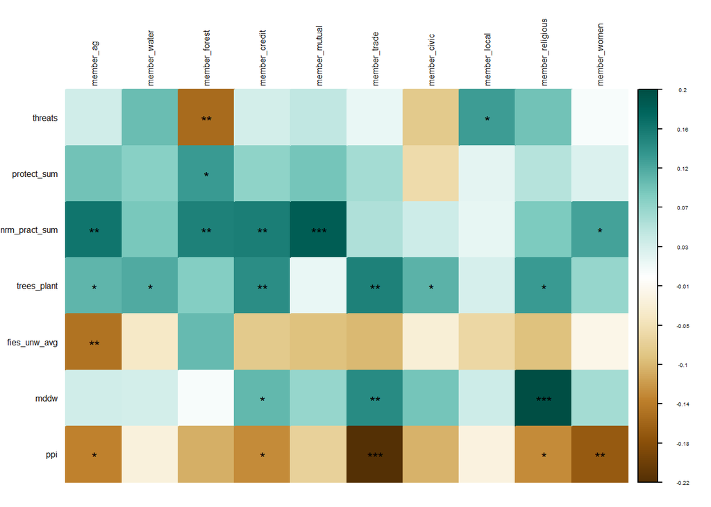

```r
MG <- cor(member_groups)

testResMG <- cor.mtest(member_groups, conf.level = 0.95)

corrplot(MG[11:17, 1:10, drop=FALSE], method = 'color', p.mat = testResMG$p[11:17,1:10], tl.cex = 0.5, insig = 'label_sig', sig.level = c(0.001, 0.01, 0.05), pch.cex = 0.8, number.cex = 0.5, is.corr = FALSE, col = COL2('BrBG'), cl.pos = 'r', cl.cex = 0.3, tl.col = "black")
```

#### MDDW and Religion

In the chunk above, I found a strong correlation between MDDW and membership in a religious group, so I wanted to look into it further.

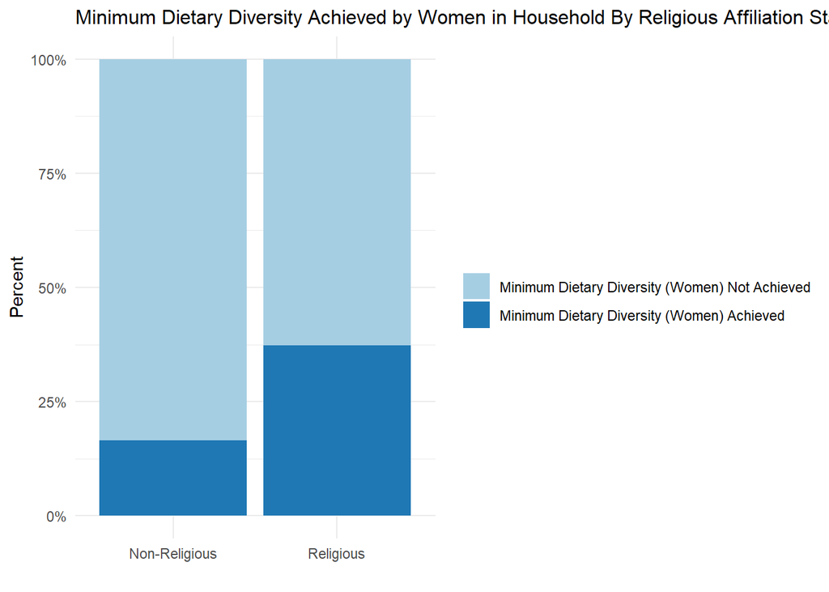

```r
final_member%>%
  filter(!is.na(mddw))%>%
  ggplot(aes(x = as_factor(member_religious), fill = as_factor(mddw)))+
  geom_bar(position = 'fill')+
  scale_fill_brewer(palette = "Paired", name = "", labels = c("Minimum Dietary Diversity (Women) Not Achieved", "Minimum Dietary Diversity (Women) Achieved"))+
  labs(title = "Minimum Dietary Diversity Achieved by Women in Household By Religious Affiliation Status", y = "Percent")+
  scale_y_continuous(labels = scales::percent)+
  theme_minimal()+
  theme(plot.title = element_text(size = 12))+
  scale_x_discrete(labels = c("Non-Religious", "Religious"), name = "")
```

```r
# percent of members who achieved minimum dietary diversity
final_member%>%
  group_by(member_any)%>%
  summarise(mean(mddw, na.rm = TRUE), n())
```

```
## # A tibble: 2 x 3
##   member_any `mean(mddw, na.rm = TRUE)` `n()`
##        <dbl>                      <dbl> <int>
## 1          0                     0.0696   203
## 2          1                     0.279    552
```

```r
# percent of religious members who achieved minimum dietary diversity
final_member%>%
  group_by(member_religious)%>%
  summarise(mean(mddw, na.rm = TRUE), n())
```

```
## # A tibble: 2 x 3
##   member_religious `mean(mddw, na.rm = TRUE)` `n()`
##   <dbl+lbl>                             <dbl> <int>
## 1 0 [No]                                0.166   521
## 2 1 [Yes]                               0.373   234
```

#### Does the number of groups matter?

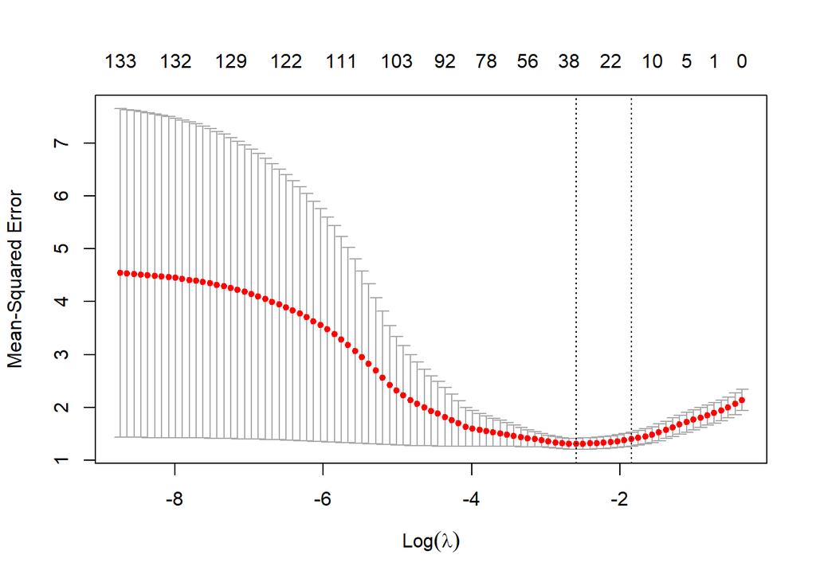

```r
y <- final_member$member_sum

final_predict <- final_member%>%
  select(gender_hh_type:member_other2, trees_a:trees_y, trees_why_a:trees_why_k, trees_why_perm:land, land_kind_a:land_kind_b, clear, clear_why_a:clear_why_z, clear_where_a:clear_where_z, clear_protect:honey_why, mush:mush_why, insects:insects_why, fruits:fruits_why, meat:meat_why, plants:plants_why, fish:fish_why, wood:wood_why, char:char_why, protect_water:loss, threats, threats_illegal_logging:threats_resource_use, fuel_sources_1:fuel_sources_6, fuel_sources2_1:fuel_women_hours, ppi:mddw, -starts_with("member"))%>%
  replace(is.na(.), 0)%>%
  na.omit(.)
x <- data.matrix(final_predict)

cv_model <- cv.glmnet(x, y, alpha = 1)
best_lambda <- cv_model$lambda.min
plot(cv_model)
```

```r
best_model <- glmnet(x, y, alpha = 1, lambda = best_lambda)
coef(best_model)
```

```
## 153 x 1 sparse Matrix of class "dgCMatrix"
##                                        s0
## (Intercept)                   3.131856447
## gender_hh_type                .
## ed_level_head                 0.007318241
## work_head                     .
## paid_head                     0.010116637
## read_head                     0.168097940
## fokontany_deid                .
## nrm_pract_a                   0.013379190
## nrm_pract_b                   0.029743278
## nrm_pract_c                   .
## nrm_pract_d                   .
## nrm_pract_e                   .
## nrm_pract_f                   0.156922304
## nrm_pract_g                   .
## nrm_pract_sum                 0.070808128
## nrm_pract_y                   .
## loan_ngo                     -0.244688960
## loan_informal                 .
## loan_formal                  -0.060280111
## loan_friend                   .
## loan_group                   -0.395188266
## loan_sav                      .
## trees_a                       .
## trees_b                       0.592759084
## trees_c                       0.024420510
## trees_d                       0.017102915
## trees_y                       .
## trees_why_a                   .
## trees_why_b                   0.002951776
## trees_why_c                   .
## trees_why_d                   .
## trees_why_e                   .
## trees_why_f                   .
## trees_why_g                   .
## trees_why_h                   .
## trees_why_i                   0.080365100
## trees_why_j                   .
## trees_why_k                   .
```

[output cut: 100 more lines]

```
## ppi                           .
## probability_not_in_poverty    0.417670443
## fies_enough                   .
## fies_healthy                  .
## fies_few                      .
## fies_skip                     .
## fies_less                    -0.103655499
## fies_no                       .
## fies_hungry                   .
## fies_day                      .
## fies_unw_avg                  .
## how_food_secure               .
## CSI                           .
## birth                         .
## mddw                          .
```

```r
as.data.frame(as.matrix(coef(best_model)))%>%
  arrange(desc(s0))
```

```
##                                        s0
## (Intercept)                   3.131856447
## trees_b                       0.592759084
## probability_not_in_poverty    0.417670443
## fuel_sources_5                0.395746074
## fuel_sources_6                0.188534069
## read_head                     0.168097940
## loss                          0.164992867
## nrm_pract_f                   0.156922304
## threats                       0.154925274
## clear_where_c                 0.141728556
## fuel_women_6                  0.126768029
## trees_why_perm                0.112868989
## fruits_access                 0.091704378
## wood_access                   0.083343484
## trees_why_i                   0.080365100
## char_why                      0.071861462
## nrm_pract_sum                 0.070808128
## fish_why                      0.061578429
## protect_plants                0.041949150
## threats_slash_burn            0.041594584
## wood_why                      0.038768662
## land                          0.031921840
## nrm_pract_b                   0.029743278
## trees_c                       0.024420510
## clear_why_c                   0.021488900
## trees_d                       0.017102915
## nrm_pract_a                   0.013379190
## paid_head                     0.010116637
## plants_why                    0.007436340
## ed_level_head                 0.007318241
## trees_why_b                   0.002951776
## meat_why                      0.001083532
## gender_hh_type                0.000000000
## work_head                     0.000000000
## fokontany_deid                0.000000000
## nrm_pract_c                   0.000000000
## nrm_pract_d                   0.000000000
## nrm_pract_e                   0.000000000
## nrm_pract_g                   0.000000000
```

[output cut: 99 more lines]

```
## fies_skip                     0.000000000
## fies_no                       0.000000000
## fies_hungry                   0.000000000
## fies_day                      0.000000000
## fies_unw_avg                  0.000000000
## how_food_secure               0.000000000
## CSI                           0.000000000
## birth                         0.000000000
## mddw                          0.000000000
## clear_where_z                -0.048050406
## fuel_sources2_1              -0.055511478
## loan_formal                  -0.060280111
## fies_less                    -0.103655499
## loan_ngo                     -0.244688960
## loan_group                   -0.395188266
```

```r
# nope. lasso looked largely the same
```